# Simulating Mixed Effects

Lisa DeBruine

Generate data for a Stroop task where people (`subjects`) say the colour of colour words (`stimuli`) shown in each of two versions (`congruent` and `incongruent`). Subjects are in one of two conditions (`hard` and `easy`). The dependent variable (`DV`) is reaction time.

## Setup

```r
library(tidyverse) # for data wrangling, pipes, and good dataviz
library(lmerTest)  # for mixed effect models
library(broom.mixed) # for getting tidy data tables from mixed models
# devtools::install_github("debruine/faux")
library(faux)      # for simulating correlated variables

options("scipen"=10, "digits"=4) # control scientific notation
set.seed(8675309) # Jenny, I've got your number
```

## Random intercepts

### Subjects

First, we need to generate a sample of subjects. Each subject will have slightly faster or slower reaction times on average; this is their random intercept (`sub_i`). We’ll model it from a normal distribution with a mean of 0 and SD of 100ms.

We also add between-subject variables here. Each subject is in only one condition, so assign half `easy` and half `hard`. Set the number of subjects as `sub_n` at the beginning so you can change this in the future with only one edit.

```r
sub_n  <- 200 # number of subjects in this simulation
sub_sd <- 100 # SD for the subjects' random intercept

sub <- tibble(
  sub_id = 1:sub_n,
  sub_i  = rnorm(sub_n, 0, sub_sd), # random intercept
  sub_cond = rep(c("easy","hard"), each = sub_n/2) # between-subjects factor
)
```

I like to check my simulations at every step with a graph. We expect subjects in `hard` and `easy` conditions to have approximately equal intercepts.

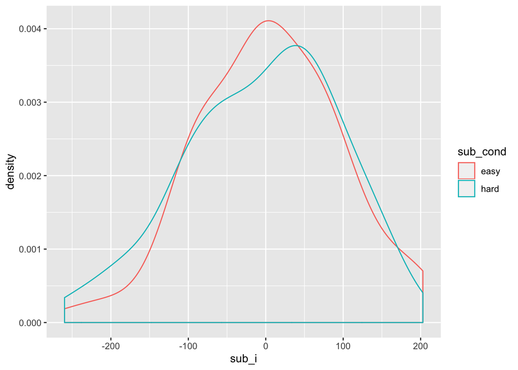

Double-check subject intercepts

```r
ggplot(sub, aes(sub_i, color = sub_cond)) +
  geom_density()
```

### Stimuli

Now, we generate a sample of stimuli. Each stimulus will have slightly faster or slower reaction times on average; this is their random intercept (`stim_i`). We’ll model it from a normal distribution with a mean of 0 and SD of 50ms (it seems reasonable to expect less variability between words than people for this task). Stimulus version (`congruent` vs `incongruent`) is a within-stimulus variable, so we don’t need to add it here.

```r
stim_n  <- 50 # number of stimuli in this simulation
stim_sd <- 50 # SD for the stimuli's random intercept

stim <- tibble(
  stim_id = 1:stim_n,
  stim_i = rnorm(stim_n, 0, stim_sd) # random intercept
)
```

Plot the random intercepts to double-check they look like you expect.

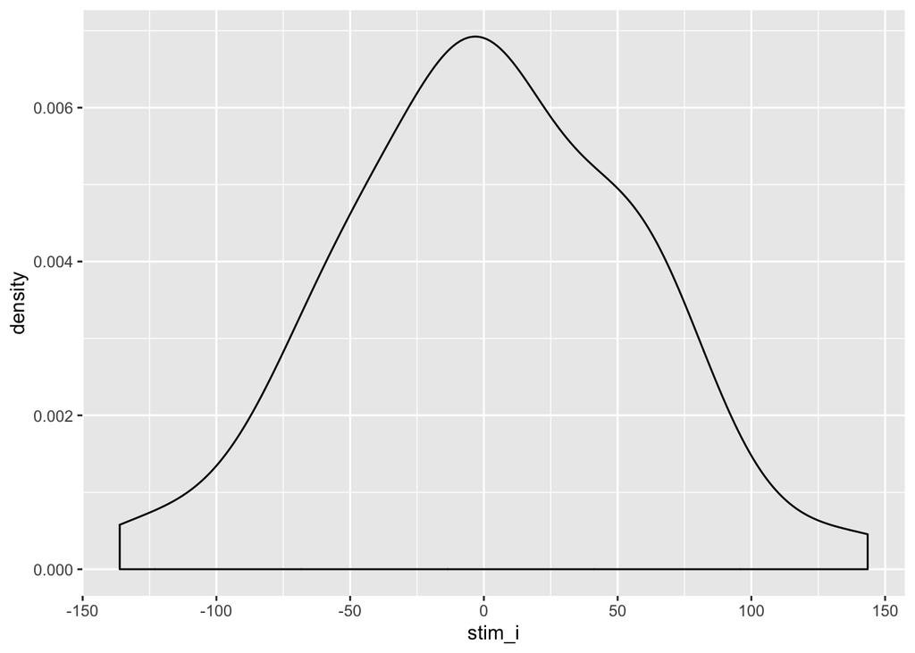

Double-check stimulus intercepts

```r
ggplot(stim, aes(stim_i)) +
  geom_density()
```

### Trials

```r
trials <- crossing(
  sub_id = sub$sub_id, # get subject IDs from the sub data table
  stim_id = stim$stim_id, # get stimulus IDs from the stim data table
  stim_version = c("congruent", "incongruent") # all subjects see both congruent and incongruent versions of all stimuli
) %>%
  left_join(sub, by = "sub_id") %>% # includes the intercept and conditin for each subject
  left_join(stim, by = "stim_id")   # includes the intercept for each stimulus
```

## Calculate DV

Now we can calculate the DV by adding together an overall intercept (mean RT for all trials), the subject-specific intercept, the stimulus-specific intercept, the effect of subject condition, the interaction between condition and version (set to 0 for this first example), the effect of stimulus version, and an error term.

### Fixed effects

```r
# set variables to use in calculations below
grand_i          <- 400 # overall mean DV
sub_cond_eff     <- 50  # mean difference between conditions: hard - easy
stim_version_eff <- 50  # mean difference between versions: incongruent - congruent
cond_version_ixn <-  0  # interaction between version and condition
error_sd         <- 25  # residual (error) SD
```

The code chunk below effect-codes the condition and version factors (important for the analysis below), generates an error term for each trial, and generates the DV.

```r
conditions <- c("hard" = -0.5, "easy" = +0.5)
versions   <- c("congruent" = -0.5, "incongruent" = +0.5)

dat <- trials %>%
  mutate(
    # effect-code subject condition and stimulus version
    sub_cond.e = recode(sub_cond, !!!conditions),
    stim_version.e = recode(stim_version, !!!versions),
    # calculate error term (normally distributed residual with SD set above)
    err = rnorm(nrow(.), 0, error_sd),
    # calculate DV from intercepts, effects, and error
    dv = grand_i + sub_i + stim_i + err +
         (sub_cond.e * sub_cond_eff) +
         (stim_version.e * stim_version_eff) +
         (sub_cond.e * stim_version.e * cond_version_ixn) # in this example, this is always 0 and could be omitted
  )
```

As always, graph to make sure you’ve simulated the general pattern you expected.

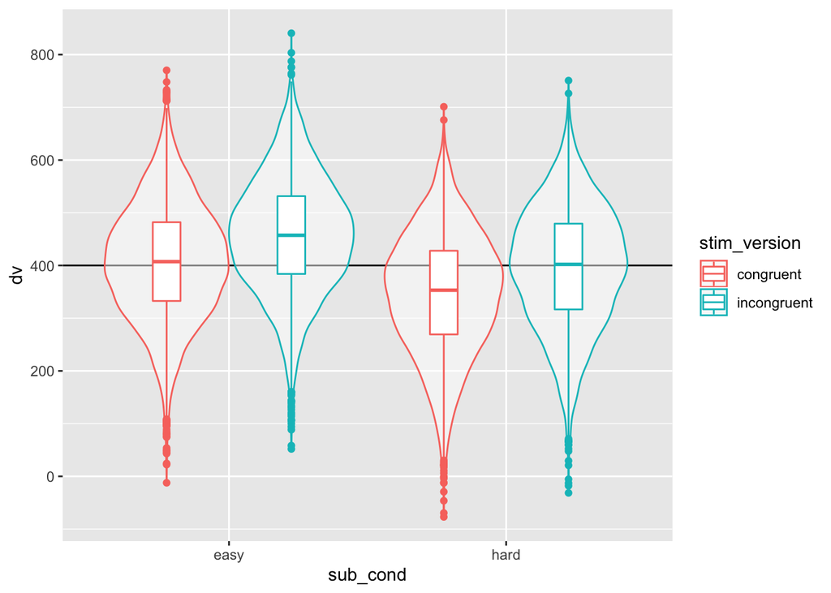

Double-check the simulated pattern

```r
ggplot(dat, aes(sub_cond, dv, color = stim_version)) +
  geom_hline(yintercept = grand_i) +
  geom_violin(alpha = 0.5) +
  geom_boxplot(width = 0.2, position = position_dodge(width = 0.9))
```

### Interactions

If you want to simulate an interaction, it can be tricky to figure out what to set the main effects and interaction effect to. It can be easier to think about the simple main effects for each cell. Create four new variables and set them to the deviations from the overall mean you’d expect for each condition (so they should add up to 0). Here, we’re simulating a small effect of version in the hard condition (50ms difference) and double that effect of version in the easy condition (100ms difference).

```r
# set variables to use in calculations below
grand_i    <- 400
hard_congr <- -25
hard_incon <- +25
easy_congr <- -50
easy_incon <- +50
error_sd   <-  25

conditions <- c("hard" = -0.5, "easy" = +0.5)
versions   <- c("congruent" = -0.5, "incongruent" = +0.5)
```

Use the code below to transform the simple main effects above into main effects and interactions for use in the equations below.

```r
# calculate main effects and interactions from simple effects above

# mean difference between easy and hard conditions
sub_cond_eff     <- (easy_congr + easy_incon)/2 -
                    (hard_congr + hard_incon)/2
# mean difference between incongruent and congruent versions
stim_version_eff <- (hard_incon + easy_incon)/2 -
                    (hard_congr + easy_congr)/2
# interaction between version and condition
cond_version_ixn <- (easy_incon - easy_congr) -
                    (hard_incon - hard_congr)
```

Then generate the DV the same way we did above, but also add the interaction effect multiplied by the effect-coded subject condition and stimulus version.

```r
dat <- trials %>%
  mutate(
    # effect-code subject condition and stimulus version
    sub_cond.e = recode(sub_cond, !!!conditions),
    stim_version.e = recode(stim_version, !!!versions),
    # calculate error term (normally distributed residual with SD set above)
    err = rnorm(nrow(.), 0, error_sd),
    # calculate DV from intercepts, effects, and error
    dv = grand_i + sub_i + stim_i + err +
         (sub_cond.e * sub_cond_eff) +
         (stim_version.e * stim_version_eff) +
         (sub_cond.e * stim_version.e * cond_version_ixn)
  )
```

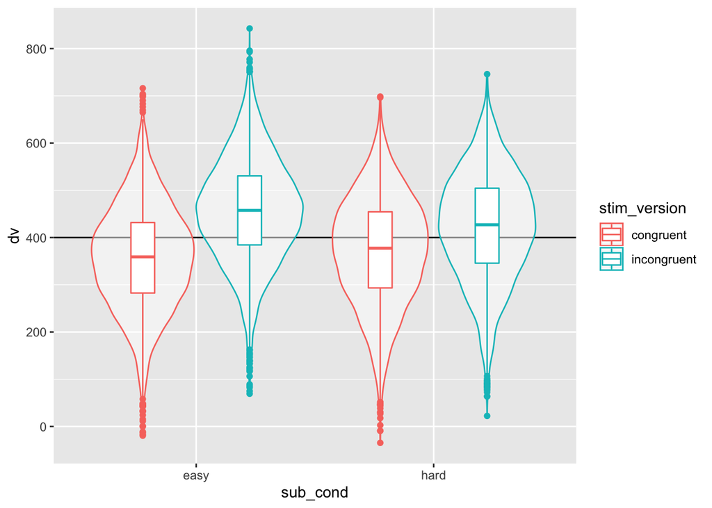

Double-check the interaction between condition and version

```r
ggplot(dat, aes(sub_cond, dv, color = stim_version)) +
  geom_hline(yintercept = grand_i) +
  geom_violin(alpha = 0.5) +
  geom_boxplot(width = 0.2, position = position_dodge(width = 0.9))
```

```r
group_by(dat, sub_cond, stim_version) %>%
  summarise(m = mean(dv) - grand_i %>% round(1)) %>%
  ungroup() %>%
  spread(stim_version, m)
```

```
## # A tibble: 2 x 3
##   sub_cond congruent incongruent
##   <chr>        <dbl>       <dbl>
## 1 easy         -42.5        57.1
## 2 hard         -28.5        21.7
```

## Analysis

New we will run a linear mixed effects model with `lmer` and look at the summary.

```r
mod <- lmer(dv ~ sub_cond.e * stim_version.e +
              (1 | sub_id) +
              (1 | stim_id),
            data = dat)

mod.sum <- summary(mod)

mod.sum
```

```
## Linear mixed model fit by REML. t-tests use Satterthwaite's method [
## lmerModLmerTest]
## Formula: dv ~ sub_cond.e * stim_version.e + (1 | sub_id) + (1 | stim_id)
##    Data: dat
##
## REML criterion at convergence: 187453
##
## Scaled residuals:
##    Min     1Q Median     3Q    Max
## -3.760 -0.663  0.006  0.659  3.714
##
## Random effects:
##  Groups   Name        Variance Std.Dev.
##  sub_id   (Intercept) 9185     95.8
##  stim_id  (Intercept) 3069     55.4
##  Residual              629     25.1
## Number of obs: 20000, groups:  sub_id, 200; stim_id, 50
##
## Fixed effects:
##                            Estimate Std. Error        df t value Pr(>|t|)
## (Intercept)                 401.937     10.360   131.461   38.80   <2e-16 ***
## sub_cond.e                   10.737     13.558   197.968    0.79     0.43
## stim_version.e               74.908      0.355 19749.013  211.19   <2e-16 ***
## sub_cond.e:stim_version.e    49.357      0.709 19749.013   69.57   <2e-16 ***
## ---
## Signif. codes:  0 '***' 0.001 '**' 0.01 '*' 0.05 '.' 0.1 ' ' 1
##
## Correlation of Fixed Effects:
##             (Intr) sb_cn. stm_v.
## sub_cond.e  0.000
## stim_versn. 0.000  0.000
## sb_cnd.:s_. 0.000  0.000  0.000
```

### Sense checks

First, check that your groups make sense.

- The number of obs should be the total number of trials analysed.
- `sub_id` should be what we set `sub_n` to above.
- `stim_id` should be what we set `stim_n` to above.

```r
mod.sum$ngrps
```

```
##  sub_id stim_id
##     200      50
```

Next, look at the random effects.

- The SD for `sub_id` should be near `sub_sd`.
- The SD for `stim_id` should be near `stim_sd`.
- The residual SD should be near `error_sd`.

```r
mod.sum$varcor
```

```
##  Groups   Name        Std.Dev.
##  sub_id   (Intercept) 95.8
##  stim_id  (Intercept) 55.4
##  Residual             25.1
```

Finally, look at the fixed effects.

- The estimate for the Intercept should be near the `grand_i`.
- The main effect of `sub_cond.e` should be near what we calculated for `sub_cond_eff`.
- The main effect of `stim_version.e` should be near what we calculated for `stim_version_eff`.
- The interaction between `sub_cond.e`:`stim_version.e` should be near what we calculated for `cond_version_ixn`.

```r
mod.sum$coefficients
```

```
##                           Estimate Std. Error      df  t value  Pr(>|t|)
## (Intercept)                 401.94    10.3599   131.5  38.7972 7.475e-74
## sub_cond.e                   10.74    13.5581   198.0   0.7919 4.294e-01
## stim_version.e               74.91     0.3547 19749.0 211.1856 0.000e+00
## sub_cond.e:stim_version.e    49.36     0.7094 19749.0  69.5750 0.000e+00
```

### Random effects

Plot the subject intercepts from our code above (`sub$sub_i`) against the subject intercepts calculcated by `lmer` (`ranef(mod)$sub_id`).

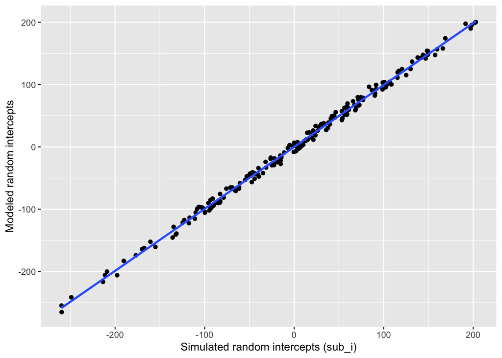

Compare simulated subject random intercepts to those from the model

```r
ranef(mod)$sub_id %>%
  as_tibble(rownames = "sub_id") %>%
  rename(mod_sub_i = `(Intercept)`) %>%
  mutate(sub_id = as.integer(sub_id)) %>%
  left_join(sub, by = "sub_id") %>%
  ggplot(aes(sub_i,mod_sub_i)) +
  geom_point() +
  geom_smooth(method = "lm") +
  xlab("Simulated random intercepts (sub_i)") +
  ylab("Modeled random intercepts")
```

Plot the stimulus intercepts from our code above (`stim$stim_i`) against the stimulus intercepts calculcated by `lmer` (`ranef(mod)$stim_id`).

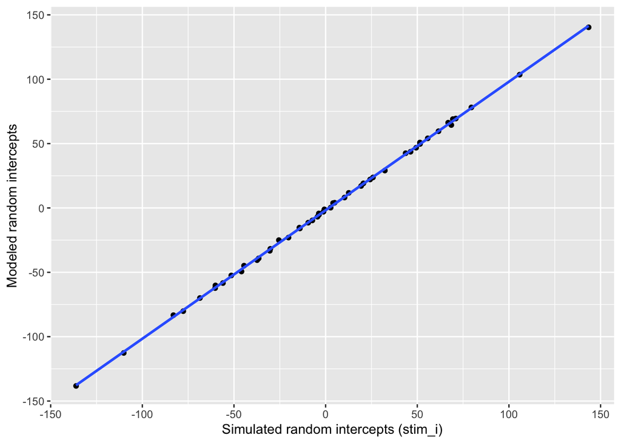

Compare simulated stimulus random intercepts to those from the model

```r
ranef(mod)$stim_id %>%
  as_tibble(rownames = "stim_id") %>%
  rename(mod_stim_i = `(Intercept)`) %>%
  mutate(stim_id = as.integer(stim_id)) %>%
  left_join(stim, by = "stim_id") %>%
  ggplot(aes(stim_i,mod_stim_i)) +
  geom_point() +
  geom_smooth(method = "lm") +
  xlab("Simulated random intercepts (stim_i)") +
  ylab("Modeled random intercepts")
```

## Function

You can put the code above in a function so you can run it more easily and change the parameters. I removed the plot and set the argument defaults to the same as the example above with all fixed effects set to 0, but you can set them to other patterns.

```r
sim_lmer <- function( sub_n = 200,
                      sub_sd = 100,
                      stim_n = 50,
                      stim_sd = 50,
                      grand_i = 400,
                      sub_cond_eff = 0,
                      stim_version_eff = 0,
                      cond_version_ixn = 0,
                      error_sd = 25) {
  sub <- tibble(
    sub_id = 1:sub_n,
    sub_i  = rnorm(sub_n, 0, sub_sd),
    sub_cond = rep(c("hard","easy"), each = sub_n/2)
  )

  stim <- tibble(
    stim_id = 1:stim_n,
    stim_i = rnorm(stim_n, 0, stim_sd)
  )

  conditions <- c("hard" = -0.5, "easy" = +0.5)
  versions   <- c("congruent" = -0.5, "incongruent" = +0.5)

  dat <- crossing(
    sub_id = sub$sub_id,
    stim_id = stim$stim_id,
    stim_version = c("congruent", "incongruent")
  ) %>%
    left_join(sub, by = "sub_id") %>%
    left_join(stim, by = "stim_id") %>%
    mutate(
      # effect-code subject condition and stimulus version
      sub_cond.e = recode(sub_cond, !!!conditions),
      stim_version.e = recode(stim_version, !!!versions),
      # calculate error term (normally distributed residual with SD set above)
      err = rnorm(nrow(.), 0, error_sd),
      # calculate DV from intercepts, effects, and error
      dv = grand_i + sub_i + stim_i + err +
           (sub_cond.e * sub_cond_eff) +
           (stim_version.e * stim_version_eff) +
           (sub_cond.e * stim_version.e * cond_version_ixn)
    )

  mod <- lmer(dv ~ sub_cond.e * stim_version.e +
                (1 | sub_id) +
                (1 | stim_id),
              data = dat)

  return(mod)
}
```

Run the function with the default values (so all fixed effects set to 0).

```r
sim_lmer() %>% summary()
```

```
## Linear mixed model fit by REML. t-tests use Satterthwaite's method [
## lmerModLmerTest]
## Formula: dv ~ sub_cond.e * stim_version.e + (1 | sub_id) + (1 | stim_id)
##    Data: dat
##
## REML criterion at convergence: 187436
##
## Scaled residuals:
##    Min     1Q Median     3Q    Max
## -4.317 -0.673  0.001  0.662  4.808
##
## Random effects:
##  Groups   Name        Variance Std.Dev.
##  sub_id   (Intercept) 8822     93.9
##  stim_id  (Intercept) 2680     51.8
##  Residual              629     25.1
## Number of obs: 20000, groups:  sub_id, 200; stim_id, 50
##
## Fixed effects:
##                            Estimate Std. Error        df t value Pr(>|t|)
## (Intercept)                 390.831      9.886   139.365   39.53   <2e-16 ***
## sub_cond.e                  -12.415     13.287   197.997   -0.93     0.35
## stim_version.e               -0.178      0.355 19749.003   -0.50     0.62
## sub_cond.e:stim_version.e    -0.351      0.709 19749.003   -0.50     0.62
## ---
## Signif. codes:  0 '***' 0.001 '**' 0.01 '*' 0.05 '.' 0.1 ' ' 1
##
## Correlation of Fixed Effects:
##             (Intr) sb_cn. stm_v.
## sub_cond.e  0.000
## stim_versn. 0.000  0.000
## sb_cnd.:s_. 0.000  0.000  0.000
```

Try changing some variables to simulate different patterns of fixed effects.

```r
sim_lmer(sub_cond_eff = 0,
         stim_version_eff = 75,
         cond_version_ixn = 50) %>%
  summary()
```

```
## Linear mixed model fit by REML. t-tests use Satterthwaite's method [
## lmerModLmerTest]
## Formula: dv ~ sub_cond.e * stim_version.e + (1 | sub_id) + (1 | stim_id)
##    Data: dat
##
## REML criterion at convergence: 187254
##
## Scaled residuals:
##    Min     1Q Median     3Q    Max
## -4.147 -0.663  0.000  0.669  3.997
##
## Random effects:
##  Groups   Name        Variance Std.Dev.
##  sub_id   (Intercept) 11708    108.2
##  stim_id  (Intercept)  2721     52.2
##  Residual               621     24.9
## Number of obs: 20000, groups:  sub_id, 200; stim_id, 50
##
## Fixed effects:
##                            Estimate Std. Error        df t value Pr(>|t|)
## (Intercept)                 407.692     10.629   164.041   38.36   <2e-16 ***
## sub_cond.e                   -7.750     15.306   197.998   -0.51     0.61
## stim_version.e               74.932      0.353 19749.000  212.55   <2e-16 ***
## sub_cond.e:stim_version.e    50.556      0.705 19749.000   71.70   <2e-16 ***
## ---
## Signif. codes:  0 '***' 0.001 '**' 0.01 '*' 0.05 '.' 0.1 ' ' 1
##
## Correlation of Fixed Effects:
##             (Intr) sb_cn. stm_v.
## sub_cond.e  0.000
## stim_versn. 0.000  0.000
## sb_cnd.:s_. 0.000  0.000  0.000
```

### Power analysis

First, wrap your simulation function inside of another function that takes the argument of a replication number, runs a simluated analysis, and returns a data table of the fixed and random effects (made with `broom.mixed::tidy()`). You can use purrr’s `map_df()` function to create a data table of results from multiple replications of this function. We’re only running 10 replications here in the interests of time, but you’ll want to run 100 or more for a proper power calcuation.

```r
sim_lmer_pwr <- function(rep) {
  s <- sim_lmer(sub_cond_eff = 0,
                stim_version_eff = 75,
                cond_version_ixn = 50)

  # put just the fixed effects into a data table
  broom.mixed::tidy(s, "fixed") %>%
    mutate(rep = rep) # add a column for which rep
}

my_power <- map_df(1:10, sim_lmer_pwr)
```

You can then plot the distribution of estimates across your simulations.

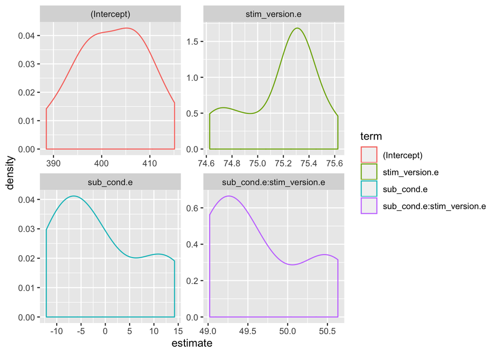

```r
ggplot(my_power, aes(estimate, color = term)) +
  geom_density() +
  facet_wrap(~term, scales = "free")
```

You can also just calculate power as the proportion of p-values less than your alpha.

```r
my_power %>%
  group_by(term) %>%
  summarise(power <- mean(p.value < 0.05))
```

```
## # A tibble: 4 x 2
##   term                      `power <- mean(p.value < 0.05)`
##   <chr>                                               <dbl>
## 1 (Intercept)                                             1
## 2 stim_version.e                                          1
## 3 sub_cond.e                                              0
## 4 sub_cond.e:stim_version.e                               1
```

## Random slopes

In the example so far we’ve ignored random variation among subjects or stimuli in the size of the fixed effects (i.e., **random slopes**).

First, let’s reset the parameters we set above.

```r
sub_n            <- 200 # number of subjects in this simulation
sub_sd           <- 100 # SD for the subjects' random intercept
stim_n           <- 50  # number of stimuli in this simulation
stim_sd          <- 50  # SD for the stimuli's random intercept
grand_i          <- 400 # overall mean DV
sub_cond_eff     <- 50  # mean difference between conditions: hard - easy
stim_version_eff <- 50  # mean difference between versions: incongruent - congruent
cond_version_ixn <-  0  # interaction between version and condition
error_sd         <- 25  # residual (error) SD
```

### Subjects

In addition to generating a random intercept for each subject, now we will also generate a random slope for any within-subject factors. The only within-subject factor in this design is `stim_version`. The main effect of `stim_version` is set to 50 above, but different subjects will show variation in the size of this effect. That’s what the random slope captures. We’ll set `sub_version_sd` below to the SD of this variation and use this to calculate the random slope (`sub_version_slope`) for each subject.

The code below creates two variables (`sub_i`, `sub_version_slope`) that are correlated with r = -0.2, means of 0, and SDs equal to what we set `sub_sd` above and `sub_version_sd` below.

```r
sub_version_sd <- 20
sub_i_version_cor <- -0.2

sub <- faux::rnorm_multi(
  n = sub_n,
  vars = 2,
  r = sub_i_version_cor,
  mu = 0, # means of random intercepts and slopes are always 0
  sd = c(sub_sd, sub_version_sd),
  varnames = c("sub_i", "sub_version_slope")
) %>%
  mutate(
    sub_id = 1:sub_n,
    sub_cond = rep(c("easy","hard"), each = sub_n/2) # between-subjects factor
  )
```

Plot to double-check it looks sensible.

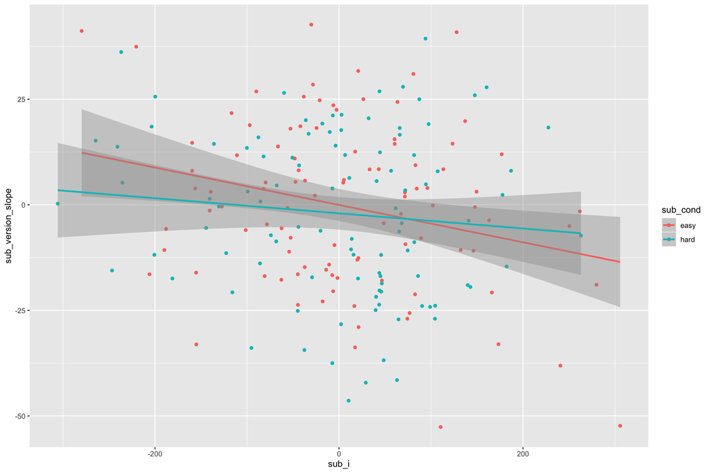

Double-check slope-intercept correlations

```r
ggplot(sub, aes(sub_i, sub_version_slope, color = sub_cond)) +
  geom_point() +
  geom_smooth(method = lm)
```

### Stimuli

In addition to generating a random intercept for each stimulus, we will also generate a random slope for any within-stimulus factors. Both `stim_version` and `sub_condition` are within-stimulus factors (i.e., all stimuli are seen in both `congruent` and `incongruent` versions and both `easy` and `hard` conditions). So the main effects of version and condition (and their interaction) will vary depending on the stimulus.

They will also be correlated, but in a more complex way than above. You need to set the correlations for all pairs of slopes and intercept. Let’s set the correlation between the random intercept and each of the slopes to -0.4 and the slopes all correlate with each other +0.2 (You could set each of the six correlations separately if you want, though).

```r
stim_version_sd <- 10 # SD for the stimuli's random slope for stim_version
stim_cond_sd <- 30 # SD for the stimuli's random slope for sub_cond
stim_cond_version_sd <- 15 # SD for the stimuli's random slope for sub_cond:stim_version
stim_i_cor <- -0.4 # correlations between intercept and slopes
stim_s_cor <- +0.2 # correlations among slopes

# specify correlations for rnorm_multi (one of several methods)
stim_cors <- c(stim_i_cor, stim_i_cor, stim_i_cor,
                           stim_s_cor, stim_s_cor,
                                       stim_s_cor)
stim <- rnorm_multi(
  n = stim_n,
  vars = 4,
  r = stim_cors,
  mu = 0, # means of random intercepts and slopes are always 0
  sd = c(stim_sd, stim_version_sd, stim_cond_sd, stim_cond_version_sd),
  varnames = c("stim_i", "stim_version_slope", "stim_cond_slope", "stim_cond_version_slope")
) %>%
  mutate(
    stim_id = 1:stim_n
  )
```

Check your stimulated data using faux’s `check_sim_stats()` function. Here, we’re simulating different SDs for different effects, so our summary table should reflect this.

```r
select(stim, -stim_id) %>% # remove id
  check_sim_stats() %>%    # calculates means, SDs and correlations
  rename(i = 3, v = 4, c = 5, cv = 6) # rename columns to fit width
```

```
## # A tibble: 4 x 8
##       n var                         i     v     c    cv   mean    sd
##   <dbl> <chr>                   <dbl> <dbl> <dbl> <dbl>  <dbl> <dbl>
## 1    50 stim_i                   1    -0.49 -0.07 -0.35  8.14  45.0
## 2    50 stim_version_slope      -0.49  1    -0.06  0.3  -0.580  9.65
## 3    50 stim_cond_slope         -0.07 -0.06  1    -0.07 -0.69  25.7
## 4    50 stim_cond_version_slope -0.35  0.3  -0.07  1     0.99  13.8
```

### Trials

Now we put the subjects and stimuli together in the same way as before.

```r
trials <- crossing(
  sub_id = sub$sub_id, # get subject IDs from the sub data table
  stim_id = stim$stim_id, # get stimulus IDs from the stim data table
  stim_version = c("congruent", "incongruent") # all subjects see both congruent and incongruent versions of all stimuli
) %>%
  left_join(sub, by = "sub_id") %>% # includes the intercept, slope, and conditin for each subject
  left_join(stim, by = "stim_id")   # includes the intercept and slopes for each stimulus
```

## Calculate DV

```r
conditions <- c("hard" = -0.5, "easy" = +0.5)
versions <- c("congruent" = -0.5, "incongruent" = +0.5)

dat <- trials %>%
  mutate(
    # effect-code subject condition and stimulus version
    sub_cond.e = recode(sub_cond, !!!conditions),
    stim_version.e = recode(stim_version, !!!versions),
    # calculate trial-specific effects by adding overall effects and slopes
    cond_eff = sub_cond_eff + stim_cond_slope,
    version_eff = stim_version_eff + stim_version_slope + sub_version_slope,
    cond_version_eff = cond_version_ixn + stim_cond_version_slope,
    # calculate error term (normally distributed residual with SD set above)
    err = rnorm(nrow(.), 0, error_sd),
    # calculate DV from intercepts, effects, and error
    dv = grand_i + sub_i + stim_i + err +
         (sub_cond.e * cond_eff) +
         (stim_version.e * version_eff) +
         (sub_cond.e * stim_version.e * cond_version_eff)
  )
```

As always, graph to make sure you’ve simulated the general pattern you expected.

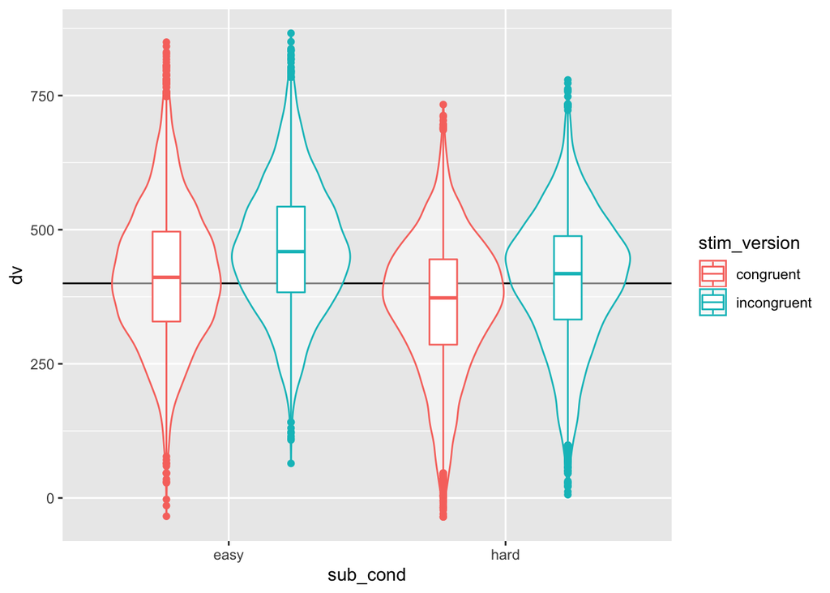

Double-check the simulated pattern

```r
ggplot(dat, aes(sub_cond, dv, color = stim_version)) +
  geom_hline(yintercept = grand_i) +
  geom_violin(alpha = 0.5) +
  geom_boxplot(width = 0.2, position = position_dodge(width = 0.9))
```

## Analysis

New we’ll run a linear mixed effects model with `lmer` and look at the summary. You specify random slopes by adding the within-level effects to the random intercept specifications. Since the only within-subject factor is version, the random effects specification for subjects is `(1 + stim_version.e | sub_id)`. Since both condition and version are within-stimuli factors, the random effects specification for stimuli is `(1 + stim_version.e*sub_cond.e | stim_id)`.

This model will take a lot longer to run than one without random slopes specified.

```r
mod <- lmer(dv ~ sub_cond.e * stim_version.e +
              (1 + stim_version.e | sub_id) +
              (1 + stim_version.e*sub_cond.e | stim_id),
            data = dat)
mod.sum <- summary(mod)

mod.sum
```

```
## Linear mixed model fit by REML. t-tests use Satterthwaite's method [
## lmerModLmerTest]
## Formula: dv ~ sub_cond.e * stim_version.e + (1 + stim_version.e | sub_id) +
##     (1 + stim_version.e * sub_cond.e | stim_id)
##    Data: dat
##
## REML criterion at convergence: 188265
##
## Scaled residuals:
##    Min     1Q Median     3Q    Max
## -3.762 -0.668  0.001  0.673  3.605
##
## Random effects:
##  Groups   Name                      Variance Std.Dev. Corr
##  sub_id   (Intercept)               12769.9  113.00
##           stim_version.e              386.3   19.66   -0.18
##  stim_id  (Intercept)                2018.2   44.92
##           stim_version.e               89.4    9.45   -0.51
##           sub_cond.e                  641.2   25.32   -0.06 -0.04
##           stim_version.e:sub_cond.e   188.0   13.71   -0.32  0.26 -0.10
##  Residual                             621.8   24.94
## Number of obs: 20000, groups:  sub_id, 200; stim_id, 50
##
## Fixed effects:
##                           Estimate Std. Error     df t value Pr(>|t|)
## (Intercept)                 411.35      10.21 201.56   40.29  < 2e-16 ***
## sub_cond.e                   56.59      16.38 216.35    3.45  0.00066 ***
## stim_version.e               47.71       1.96 153.99   24.34  < 2e-16 ***
## sub_cond.e:stim_version.e     1.19       3.46 201.93    0.34  0.73068
## ---
## Signif. codes:  0 '***' 0.001 '**' 0.01 '*' 0.05 '.' 0.1 ' ' 1
##
## Correlation of Fixed Effects:
##             (Intr) sb_cn. stm_v.
## sub_cond.e  -0.009
## stim_versn. -0.317 -0.005
## sb_cnd.:s_. -0.113 -0.152  0.101
## convergence code: 0
## Model failed to converge with max|grad| = 0.0102801 (tol = 0.002, component 1)
```

### Sense checks

First, check that your groups make sense.

- `sub_id` = `sub_n` (200)
- `stim_id` = `stim_n` (50)

```r
mod.sum$ngrps
```

```
##  sub_id stim_id
##     200      50
```

Next, look at the SDs for the random effects.

- Group:`sub_id`
  - `(Intercept)` ~= `sub_sd`
  - `stim_version.e` ~= `sub_version_sd`
- Group: `stim_id`
  - `(Intercept)` ~= `stim_sd`
  - `stim_version.e` ~= `stim_version_sd`
  - `sub_cond.e` ~= `stim_cond_sd`
  - `stim_version.e:sub_cond.e` ~= `stim_cond_version_sd`
- Residual ~= `error_sd`

```r
mod.sum$varcor
```

```
##  Groups   Name                      Std.Dev. Corr
##  sub_id   (Intercept)               113.00
##           stim_version.e             19.66   -0.18
##  stim_id  (Intercept)                44.92
##           stim_version.e              9.45   -0.51
##           sub_cond.e                 25.32   -0.06 -0.04
##           stim_version.e:sub_cond.e  13.71   -0.32  0.26 -0.10
##  Residual                            24.94
```

The correlations are a bit more difficult to parse. The first column under `Corr` shows the correlation between the random slope for that row and the random intercept. So for `stim_version.e` under `sub_id`, the correlation should be close to `sub_i_version_cor`. For all three random slopes under `stim_id`, the correlation with the random intercept should be near `stim_i_cor` and their correlations with each other should be near `stim_s_cor`.

```r
mod.sum$varcor
```

```
##  Groups   Name                      Std.Dev. Corr
##  sub_id   (Intercept)               113.00
##           stim_version.e             19.66   -0.18
##  stim_id  (Intercept)                44.92
##           stim_version.e              9.45   -0.51
##           sub_cond.e                 25.32   -0.06 -0.04
##           stim_version.e:sub_cond.e  13.71   -0.32  0.26 -0.10
##  Residual                            24.94
```

Finally, look at the fixed effects.

- `(Intercept)` ~= `grand_i`
- `sub_cond.e` ~= `sub_cond_eff`
- `stim_version.e` ~= `stim_version_eff`
- `sub_cond.e`:`stim_version.e` ~= `cond_version_ixn`

```r
mod.sum$coefficients
```

```
##                           Estimate Std. Error    df t value  Pr(>|t|)
## (Intercept)                411.351     10.210 201.6 40.2891 2.225e-98
## sub_cond.e                  56.587     16.381 216.3  3.4544 6.636e-04
## stim_version.e              47.707      1.960 154.0 24.3357 1.220e-54
## sub_cond.e:stim_version.e    1.193      3.462 201.9  0.3447 7.307e-01
```

### Random effects

Compare the subject intercepts and slopes from our code above (`sub$sub_i`) against the subject intercepts and slopes calculcated by `lmer` (`ranef(mod)$sub_id`).

```r
ranef(mod)$sub_id %>%
  as_tibble(rownames = "sub_id") %>%
  rename(mod_i = `(Intercept)`,
         mod_version_slope = stim_version.e) %>%
  mutate(sub_id = as.integer(sub_id)) %>%
  left_join(sub, by = "sub_id") %>%
  select(mod_i, sub_i,
         mod_version_slope,  sub_version_slope) %>%
  check_sim_stats() %>%    # calculates means, SDs and correlations
  rename(mod_v = 5, sub_v = 6) # rename columns to fit width
```

```
## # A tibble: 4 x 8
##       n var               mod_i sub_i mod_v sub_v  mean    sd
##   <dbl> <chr>             <dbl> <dbl> <dbl> <dbl> <dbl> <dbl>
## 1   200 mod_i              1     1    -0.18 -0.18  0    113.
## 2   200 sub_i              1     1    -0.18 -0.18  3.15 113
## 3   200 mod_version_slope -0.18 -0.18  1     0.96  0     19.0
## 4   200 sub_version_slope -0.18 -0.18  0.96  1    -1.18  19.5
```

Compare the stimulus intercepts and slopes from our code above (`stim$stim_i`) against the stimulus intercepts and slopes calculcated by `lmer` (`ranef(mod)$stim_id`).

```r
ranef(mod)$stim_id %>%
  as_tibble(rownames = "stim_id") %>%
  rename(mod_i = `(Intercept)`,
         mod_version_slope = stim_version.e,
         mod_cond_slope = sub_cond.e,
         mod_cond_version_slope = `stim_version.e:sub_cond.e`) %>%
  mutate(stim_id = as.integer(stim_id)) %>%
  left_join(stim, by = "stim_id") %>%
  select(mod_i, stim_i,
         mod_version_slope, stim_version_slope,
         mod_cond_slope, stim_cond_slope,
         mod_cond_version_slope, stim_cond_version_slope) %>%
  check_sim_stats() %>%    # calculates means, SDs and correlations
  rename(mod_v = 5, stim_v = 6,
         mod_c = 7, stim_c = 8,
         mod_cv = 9, stim_cv = 10) # rename columns to fit width
```

```
## # A tibble: 8 x 12
##       n var   mod_i stim_i  mod_v stim_v mod_c stim_c mod_cv stim_cv   mean
##   <dbl> <chr> <dbl>  <dbl>  <dbl>  <dbl> <dbl>  <dbl>  <dbl>   <dbl>  <dbl>
## 1    50 mod_i  1      1    -0.53  -0.49  -0.07  -0.07 -0.34    -0.35  0
## 2    50 stim…  1      1    -0.53  -0.49  -0.06  -0.07 -0.35    -0.35  8.14
## 3    50 mod_… -0.53  -0.53  1      0.97  -0.04  -0.03  0.290    0.32  0
## 4    50 stim… -0.49  -0.49  0.97   1     -0.06  -0.06  0.290    0.3  -0.580
## 5    50 mod_… -0.07  -0.06 -0.04  -0.06   1      1    -0.1     -0.06  0
## 6    50 stim… -0.07  -0.07 -0.03  -0.06   1      1    -0.1     -0.07 -0.69
## 7    50 mod_… -0.34  -0.35  0.290  0.290 -0.1   -0.1   1        0.94  0
## 8    50 stim… -0.35  -0.35  0.32   0.3   -0.06  -0.07  0.94     1     0.99
## # … with 1 more variable: sd <dbl>
```

## Function

You can put the code above in a function so you can run it more easily and change the parameters. I removed the plot and set the argument defaults to the same as the example above, but you can set them to other patterns.

```r
sim_lmer_slope <- function( sub_n = 200,
                            sub_sd = 100,
                            sub_version_sd = 20,
                            sub_i_version_cor = -0.2,
                            stim_n = 50,
                            stim_sd = 50,
                            stim_version_sd = 10,
                            stim_cond_sd = 30,
                            stim_cond_version_sd = 15,
                            stim_i_cor = -0.4,
                            stim_s_cor = +0.2,
                            grand_i = 400,
                            sub_cond_eff = 0,
                            stim_version_eff = 0,
                            cond_version_ixn = 0,
                            error_sd = 25) {
  sub <- rnorm_multi(
    n = sub_n,
    vars = 2,
    cors = sub_i_version_cor,
    mu = 0, # means of random intercepts and slopes are always 0
    sd = c(sub_sd, sub_version_sd),
    varnames = c("sub_i", "sub_version_slope")
  ) %>%
    mutate(
      sub_id = 1:sub_n,
      sub_cond = rep(c("easy","hard"), each = sub_n/2) # between-subjects factor
    )

  stim_cors <- c(stim_i_cor, stim_i_cor, stim_i_cor,
                             stim_s_cor, stim_s_cor,
                                         stim_s_cor)
  stim <- rnorm_multi(
    n = stim_n,
    vars = 4,
    cors = stim_cors,
    mu = 0, # means of random intercepts and slopes are always 0
    sd = c(stim_sd, stim_version_sd, stim_cond_sd, stim_cond_version_sd),
    varnames = c("stim_i", "stim_version_slope", "stim_cond_slope", "stim_cond_version_slope")
  ) %>%
    mutate(
      stim_id = 1:stim_n
    )

  trials <- crossing(
    sub_id = sub$sub_id, # get subject IDs from the sub data table
    stim_id = stim$stim_id, # get stimulus IDs from the stim data table
    stim_version = c("congruent", "incongruent") # all subjects see both congruent and incongruent versions of all stimuli
  ) %>%
    left_join(sub, by = "sub_id") %>% # includes the intercept, slope, and conditin for each subject
    left_join(stim, by = "stim_id")   # includes the intercept and slopes for each stimulus

  conditions <- c("hard" = -0.5, "easy" = +0.5)
  versions   <- c("congruent" = -0.5, "incongruent" = +0.5)

  dat <- trials %>%
    mutate(
      # effect-code subject condition and stimulus version
      sub_cond.e = recode(sub_cond, !!!conditions),
      stim_version.e = recode(stim_version, !!!versions),
      # calculate trial-specific effects by adding overall effects and slopes
      cond_eff = sub_cond_eff + stim_cond_slope,
      version_eff = stim_version_eff + stim_version_slope + sub_version_slope,
      cond_version_eff = cond_version_ixn + stim_cond_version_slope,
      # calculate error term (normally distributed residual with SD set above)
      err = rnorm(nrow(.), 0, error_sd),
      # calculate DV from intercepts, effects, and error
      dv = grand_i + sub_i + stim_i + err +
           (sub_cond.e * cond_eff) +
           (stim_version.e * version_eff) +
           (sub_cond.e * stim_version.e * cond_version_eff)
    )

  mod <- lmer(dv ~ sub_cond.e * stim_version.e +
                (1 + stim_version.e | sub_id) +
                (1 + stim_version.e*sub_cond.e | stim_id),
              data = dat)

  return(mod)
}
```

Run the function with the default values (null fixed effects).

```r
sim_lmer_slope() %>% summary()
```

```
## Linear mixed model fit by REML. t-tests use Satterthwaite's method [
## lmerModLmerTest]
## Formula: dv ~ sub_cond.e * stim_version.e + (1 + stim_version.e | sub_id) +
##     (1 + stim_version.e * sub_cond.e | stim_id)
##    Data: dat
##
## REML criterion at convergence: 188326
##
## Scaled residuals:
##    Min     1Q Median     3Q    Max
## -3.587 -0.672  0.002  0.669  3.877
##
## Random effects:
##  Groups   Name                      Variance Std.Dev. Corr
##  sub_id   (Intercept)               9831.0   99.2
##           stim_version.e             412.8   20.3     -0.18
##  stim_id  (Intercept)               2028.7   45.0
##           stim_version.e              90.3    9.5     -0.30
##           sub_cond.e                 697.5   26.4     -0.21 -0.07
##           stim_version.e:sub_cond.e  198.5   14.1     -0.62  0.12  0.05
##  Residual                            625.1   25.0
## Number of obs: 20000, groups:  sub_id, 200; stim_id, 50
##
## Fixed effects:
##                           Estimate Std. Error     df t value Pr(>|t|)
## (Intercept)                 399.29       9.47 175.67   42.15   <2e-16 ***
## sub_cond.e                  -10.49      14.52 222.55   -0.72     0.47
## stim_version.e               -2.30       2.00 159.03   -1.15     0.25
## sub_cond.e:stim_version.e     4.31       3.57 203.69    1.21     0.23
## ---
## Signif. codes:  0 '***' 0.001 '**' 0.01 '*' 0.05 '.' 0.1 ' ' 1
##
## Correlation of Fixed Effects:
##             (Intr) sb_cn. stm_v.
## sub_cond.e  -0.036
## stim_versn. -0.230 -0.011
## sb_cnd.:s_. -0.234 -0.134  0.046
## convergence code: 0
## Model failed to converge with max|grad| = 0.00368254 (tol = 0.002, component 1)
```

Try changing some variables to simulate fixed effects.

```r
sim_lmer_slope(sub_cond_eff = 50,
               stim_version_eff = 50,
               cond_version_ixn = 0)
```

```
## Linear mixed model fit by REML ['lmerModLmerTest']
## Formula: dv ~ sub_cond.e * stim_version.e + (1 + stim_version.e | sub_id) +
##     (1 + stim_version.e * sub_cond.e | stim_id)
##    Data: dat
## REML criterion at convergence: 188400
## Random effects:
##  Groups   Name                      Std.Dev. Corr
##  sub_id   (Intercept)               94.36
##           stim_version.e            19.19    -0.18
##  stim_id  (Intercept)               43.53
##           stim_version.e             8.42    -0.40
##           sub_cond.e                33.66    -0.45  0.23
##           stim_version.e:sub_cond.e 15.47    -0.45 -0.02  0.36
##  Residual                           25.07
## Number of obs: 20000, groups:  sub_id, 200; stim_id, 50
## Fixed Effects:
##               (Intercept)                 sub_cond.e
##                     404.3                       47.0
##            stim_version.e  sub_cond.e:stim_version.e
##                      50.9                       -3.1
## convergence code 0; 1 optimizer warnings; 0 lme4 warnings
```

## Exercises

1. Calculate power for the parameters in the last example using the `sim_lmer_slope()` function.

```r
sim_lmer_slope_pwr <- function(rep) {
  s <- sim_lmer_slope(sub_cond_eff = 50,
                      stim_version_eff = 50,
                      cond_version_ixn = 0)

  # put just the fixed effects into a data table
  broom.mixed::tidy(s, "fixed") %>%
    mutate(rep = rep) # add a column for which rep
}

# run it only twice to test first in the interests of time
my_power_s <- map_df(1:2, sim_lmer_slope_pwr)
```

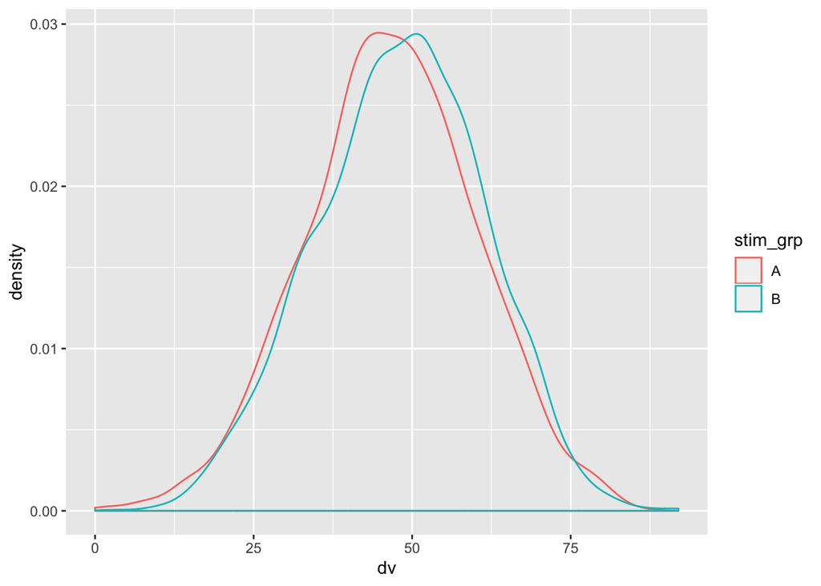

```r
grand_i <- 50
sub_n <- 50
stim_n <- 50 # in each group
sub_sd <- 5
stim_sd <- 10
err_sd <- 8
grp_effect <- 5

sub <- tibble(sub_id = 1:sub_n,
              sub_i = rnorm(sub_n, 0, sub_sd))

stim <- tibble(stim_id = 1:(stim_n*2),
               stim_grp = rep(c("A", "B"), each = stim_n),
               stim_i = rnorm(stim_n*2, 0, stim_sd))

grps <- c("A" = -0.5, "B" = +0.5)

trials <- crossing(sub_id = sub$sub_id,
                  stim_id = stim$stim_id) %>%
  left_join(sub, by = "sub_id") %>%
  left_join(stim, by = "stim_id") %>%
  mutate(grp.e = recode(stim_grp, !!!grps),
         error = rnorm(nrow(.), 0, err_sd),
         dv = grand_i + sub_i + stim_i + (grp.e * grp_effect) + error,
         # round and make sure all values are 0-100
         dv = round(dv) %>% pmax(0) %>% pmin(100))

ggplot(trials, aes(dv, color = stim_grp)) + geom_density()
```

```r
# Lisa write this soon
```

4. The package `faux` has a built-in dataset called `fr4`. Type `?faux::fr4` into the console to view the help for this dataset. Run a mixed effects model on this dataset looking at the effect of `face_sex` on ratings. Rememnber to include a random slope for the effect of face sex.

```r
sex_code <- c("male" = 0.5, "female" = -0.5)

fr_coded <- faux::fr4 %>%
  select(rater_id, face_id, face_sex, rating) %>%
  mutate(face_sex.e = recode(face_sex, !!!sex_code))

mod <- lmer(rating ~ face_sex.e +
              (1 + face_sex.e | rater_id) +
              (1 | face_id), data = fr_coded)

summary(mod)
```

```
## Linear mixed model fit by REML. t-tests use Satterthwaite's method [
## lmerModLmerTest]
## Formula: rating ~ face_sex.e + (1 + face_sex.e | rater_id) + (1 | face_id)
##    Data: fr_coded
##
## REML criterion at convergence: 2395
##
## Scaled residuals:
##    Min     1Q Median     3Q    Max
## -3.622 -0.628 -0.040  0.561  4.082
##
## Random effects:
##  Groups   Name        Variance Std.Dev. Corr
##  face_id  (Intercept) 0.362    0.602
##  rater_id (Intercept) 0.880    0.938
##           face_sex.e  0.410    0.641    0.06
##  Residual             1.044    1.022
## Number of obs: 768, groups:  face_id, 32; rater_id, 24
##
## Fixed effects:
##             Estimate Std. Error     df t value Pr(>|t|)
## (Intercept)    2.927      0.222 35.681    13.2  2.8e-15 ***
## face_sex.e    -0.599      0.260 42.643    -2.3    0.026 *
## ---
## Signif. codes:  0 '***' 0.001 '**' 0.01 '*' 0.05 '.' 0.1 ' ' 1
##
## Correlation of Fixed Effects:
##            (Intr)
## face_sex.e 0.027
```

5. Use the parameters from this analysis to simulate a new dataset with 50 male and 50 female faces, and 100 raters.

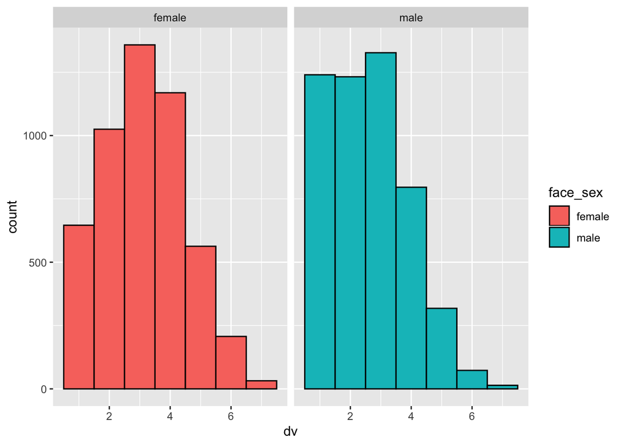

```r
# get data into a table
stats <- broom.mixed::tidy(mod)

grand_i <- filter(stats, term == "(Intercept)") %>% pull(estimate)
sub_n <- 100
stim_n <- 50 # in each group
sub_sd <- filter(stats, group == "rater_id", term == "sd__(Intercept)") %>% pull(estimate)
sub_grp_sd <- filter(stats, group == "rater_id", term == "sd__face_sex.e") %>% pull(estimate)
stim_sd <- filter(stats, group == "face_id", term == "sd__(Intercept)") %>% pull(estimate)
err_sd <- filter(stats, group == "Residual") %>% pull(estimate)
grp_effect <- filter(stats, term == "face_sex.e") %>% pull(estimate)
sex_code <- c("male" = 0.5, "female" = -0.5)


rater <- tibble(rater_id = 1:sub_n,
                rater_i = rnorm(sub_n, 0, sub_sd))

face <- tibble(face_id = 1:(stim_n*2),
               face_sex = rep(names(sex_code), each = stim_n),
               face_i = rnorm(stim_n*2, 0, stim_sd))


trials <- crossing(rater_id = rater$rater_id,
                   face_id = face$face_id) %>%
  left_join(rater, by = "rater_id") %>%
  left_join(face, by = "face_id") %>%
  mutate(face_sex.e = recode(face_sex, !!!sex_code),
         error = rnorm(nrow(.), 0, err_sd),
         dv = grand_i + rater_i + face_i + (face_sex.e * grp_effect) + error,
         # round and make sure all values are 1-7
         dv = round(dv) %>% pmax(1) %>% pmin(7))

ggplot(trials, aes(dv, fill = face_sex)) +
  geom_histogram(binwidth = 1, color = "black") +
  facet_wrap(~face_sex)
```